# Grand débat - éléments de cadrage

CB

8 avril 2019

Abstract

Cette première note de cadrage de l’analyse du contenu du corpus du grand Débat (organisation de l’Etat et des services publics) vise à donner des éléments de cadrage : a) participation, b) à partir de 3 questions fermées les grandes options managériales c) un premier coût d’oeil sur les contenus. Elle est aussi l’occasion de partager le code et de le (re)tester. Les résultats doivent être encore considérés comme provisoires, même s’ils sont stabilisés. Une prochaine note est consacrée à une analyse du sentiment, la troisième à l’utilisation d’un modèle LDA pour dégager les thématiques.

[figure not shown]

# Introduction

La crise des gilets jaunes après des semaines de manifestation le samedi sur les ronds points et les centres urbains a conduit le gouvernement à mettre en oeuvre un dispositif à mi chemin entre l’enquête ouverte et une idée de démocratie participative dont le produit objectif est la constitution d’un corpus de texte en réponse aux questions posées via ce dispositif. Il n’est pas le seul, les cahiers de doléances qui seront numérisés par la BNF, le site du vrai débat, celui de la grande annotation représentent des sources alternatives.

La faiblesse de ce corpus en termes méthodologiques vient des biais de sélection : qui y participe et pourquoi? Ainsi que des effets de cadrage : comment le questionnaire dirige les interrogations et l’opinion ? Néanmoins avec près de 100 000 contributions uniquement pour la 4ème partie (organisation de l’Etat et des services) qui nous intéresse principalement, l’objet de notre projet de recherche porte spécifiquement sur la production des représentations publiques de la gestion de l’Etat et des services public par les plateformes de la civic tech), il y a une matière précieuse à analyser.

Dans cette note de recherche, on partage le code et les élements de résultats d’un premier traitement destiné à cadrer l’analyse des contenus textuels qui sera développée dans les notes ultérieures.

On se focalise sur deux questions fermées qui ont l’avantage de cadrer les grandes options d’organisations. Centraliser ou décentraliser? Donner de l’autonomie aux acteurs ou rationnaliser leurs activités ? Une troisième définit le contexte : accède-t-on aisément aux services publics?

On retrouve de manière très simplifiée le problème de la contingence des organisations (Lawrence and Lorsch (1976)): doit-on adopter un modèle rationel et bureaucratique ou un modèle organique d’organisation? On en connait la réponse : si l’environnement est turbulent le modèle organique est capable d’inventer d’innover et de se transformer, ce qui est exiger pour survivre. Quand l’environnement est au moins prévisible, la performance opérationnelle devient le facteur de survie (Burns and Stalker (1994)).

Quand à ce document, c’est principalement un document technique, dont les résultats sont stabilisés. On y partage d’abord le code d’analyse à fin de réplication ( sur d’autres corpus) et de reproductibilité, mais aussi de pédagogie. Le détail du code est disponible sur le [projet github](https://github.com/BenaventC/GrandDebat).

Corrections et suggestions sont bienvenues. Le document est amené à évoluer.

## Initialisation des packages

## Extraction et recodage des données

## Les questions posées :

- le titre de la contribution
- l’organisation de l’état et des services publics :
  - Que pensez-vous de l’organisation de l’Etat et des administrations en France ?
  - De quelle manière cette organisation devrait-elle évoluer ? Selon vous, l’Etat doit-il aujourd’hui transférer de nouvelles missions aux collectivités territoriales (oui/non) ?
  - Si oui, lesquelles ?_
- les services manquants :
  - Estimez-vous avoir accès aux services publics dont vous avez besoin (oui/non) ?
  - Si non, quels types de services publics vous manquent dans votre territoire et qu’il est nécessaire de renforcer ?
  - Quels nouveaux services ou quelles démarches souhaitez-vous voir développées sur Internet en priorité ?
- Pouvez-vous identifier des règles que l’administration vous a déjà demandé d’appliquer et que vous avez jugées inutiles ou trop complexes ?
- Faut-il donner plus d’autonomie aux fonctionnaires de terrain ? (oui/non)
  - Si oui, comment ?
  - Faut-il revoir le fonctionnement et la formation de l’administration ?
  - Si oui, comment ? Comment l’Etat et les collectivités territoriales peuvent-ils s’améliorer pour mieux répondre aux défis de nos territoires les plus en difficulté ?
  - Avez-vous déjà utilisé certaines de ces nouvelles formes de services publics ? (oui/non)
  - Si oui, en avez-vous été satisfait ? Quelles améliorations préconiseriez-vous ?
  - Quand vous pensez à l’évolution des services publics au cours des dernières années, quels sont ceux qui ont évolué de manière positive ? Quels sont les services publics qui doivent le plus évoluer selon vous ?

Le seul élément qui caractérise l’auteur est la date de publication ainsi que le code postal. On privilégiera donc une analyse spaciale en s’interrogeant sur le bon niveau d’agrégation d’autant plus qu’une analyse sociologique de ce mouvement social a mis en avant un clivage ou un gradient ville périphérie, d’autre au contraire s’opposant à cette vision et rattachant le mouvement à des caractéristiques sociales particulières. Le niveau le plus fin est celui de la commune mais le corpus depasse à peine le nombre des communes, celui du départment est le plus aisé.

# La carte de la participation

les absents et les présents nord et sud?

un taux de participation de 4 pour 1000 habitant. Difficile de connaitre la population voir article de Bennani, Gandré, and Monnery (2019) repris par [Martin Anota](https://blogs.alternatives-economiques.fr/anota/2019/04/05/qui-a-participe-en-ligne-au-grand-debat-national)

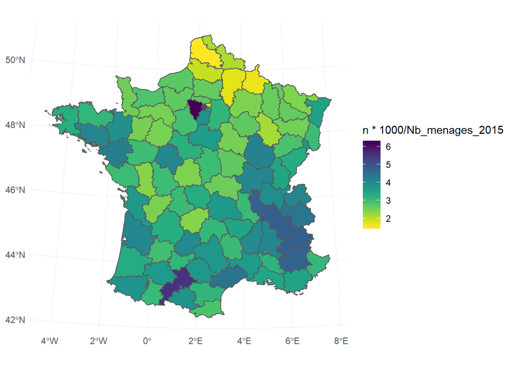

# Décentralisation, autonomie et accès au service public

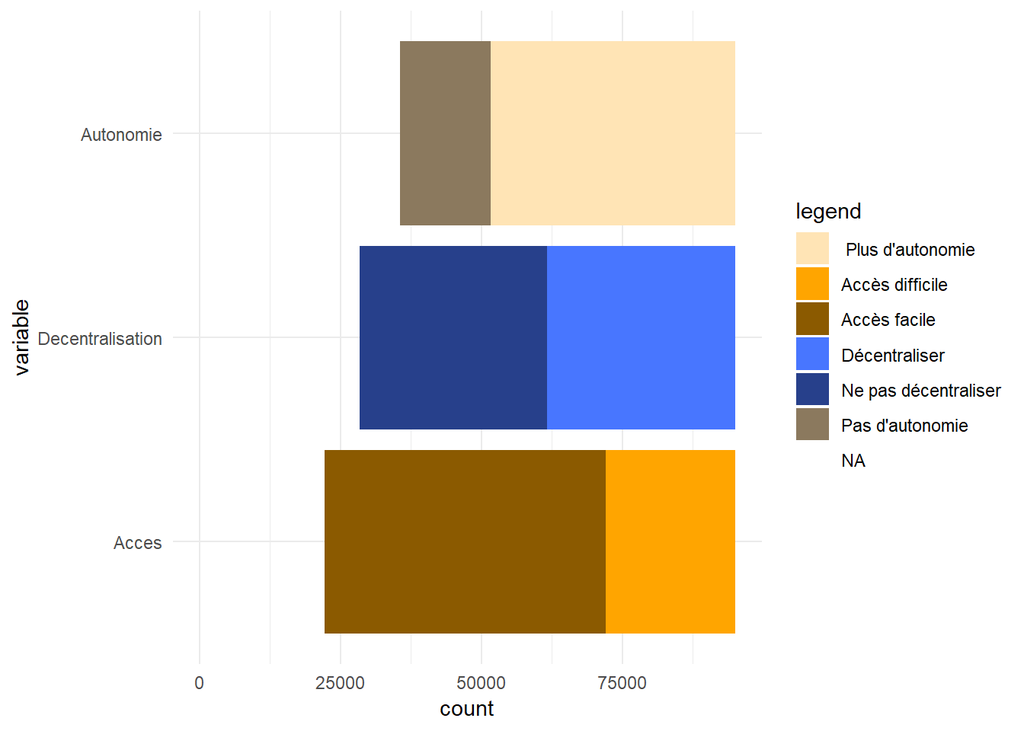

| QTransfertMission | Qautonomie | QAcces_SP | Freq |
| --- | --- | --- | --- |
| Décentraliser | Plus d'autonomie | Accès difficile | 6826 |
| Ne pas décentraliser | Plus d'autonomie | Accès difficile | 5725 |
| Décentraliser | Pas d'autonomie | Accès difficile | 1307 |
| Ne pas décentraliser | Pas d'autonomie | Accès difficile | 2868 |
| Décentraliser | Plus d'autonomie | Accès facile | 15664 |
| Ne pas décentraliser | Plus d'autonomie | Accès facile | 11114 |
| Décentraliser | Pas d'autonomie | Accès facile | 3481 |
| Ne pas décentraliser | Pas d'autonomie | Accès facile | 7442 |

Les relations entre les trois variables sont analysées avec un mosaic plot pour décomposer la contribution au chi2 et une AFCM. Manifestement les non réponse se distinguant signalent qu’elle se distribue sans doute également. Le fait principal est l’axe qui oppose décentralisation/autonomie et la rationnalisation/réduction comme on le verra plus tard. Le choix entre ces deux options n’est pas attaché à la difficulté d’accès aux services publiques. Ce choix dépend moins de la situation vécue que sans doute d’options plus fondamentales et idéologiques. Un enjeu important sera donc pour l’analyse du texte, celui de mieux cerner comment ces options se contruisent et d’identifier les argumentations qui les soutiennent.

|  | statistic |
| --- | --- |
| AccesXDecentr | c(`X-squared` = 30.14189268612) |
| AccesXAuton | c(`X-squared` = 92.0381542590938) |
| AutonXDecentr | c(`X-squared` = 2884.0542108425) |

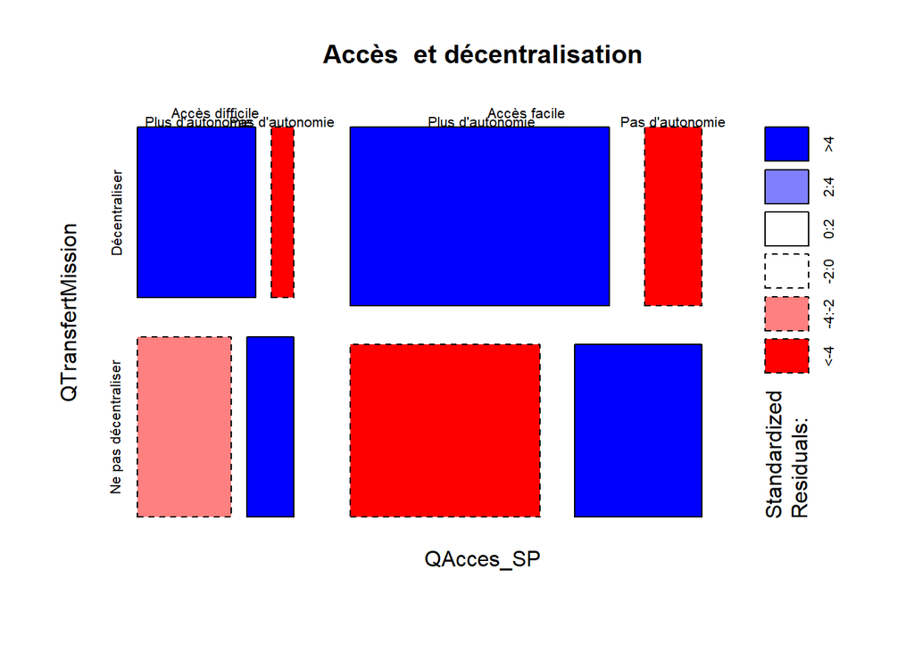

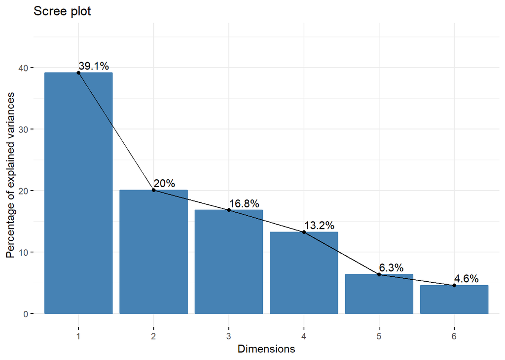

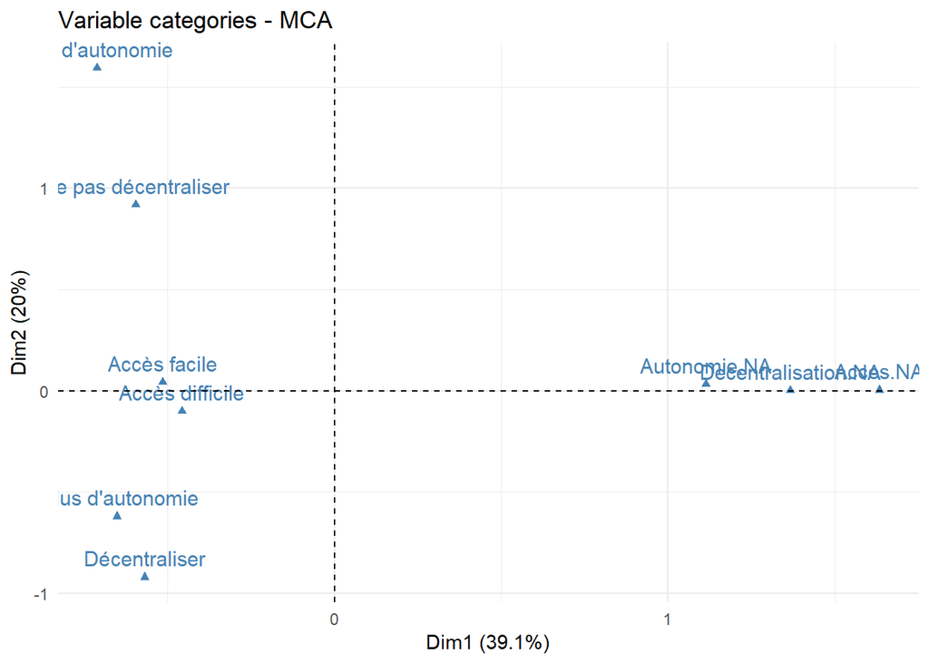

## Facilité de l’accès aux services publics

Le problème de la france centrale. Le poids des métropoles.

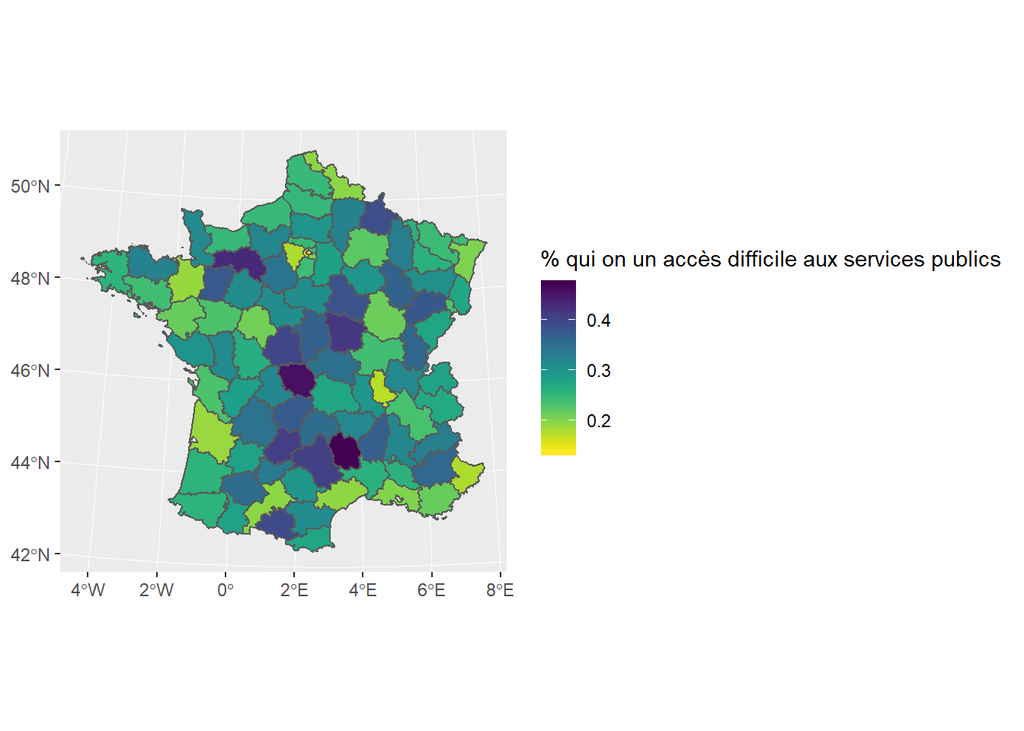

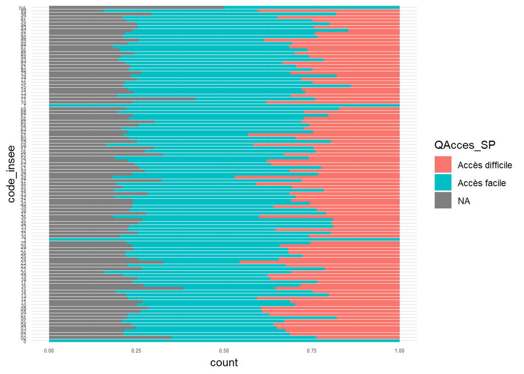

## Décentralisation

Le propre des extrémités du territoire : Bretagne et la facade atlantique, Alsace et plus généralement les départments frontalier sonts clairement en faveur d’un transfert de mission au collectivités locales. On en saisit naturellement pas les nuances.

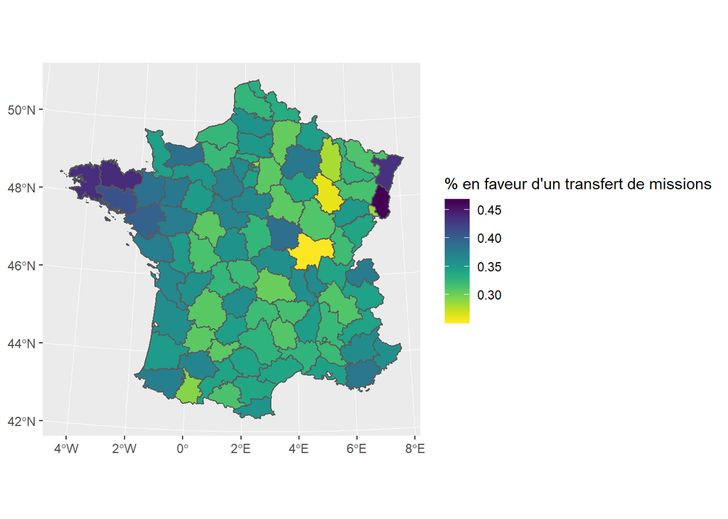

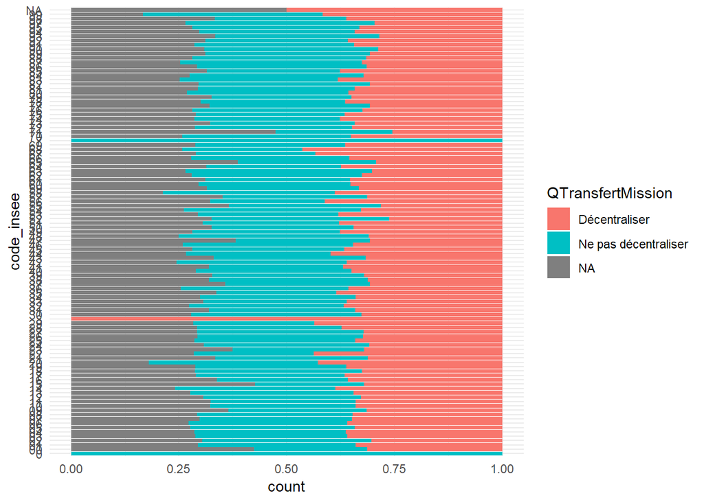

## Autonomie des fonctionnaires de terrain

l’autonomie est le fait de la france centrale et des départements éloignés des capitales régionales.

[figure not shown]

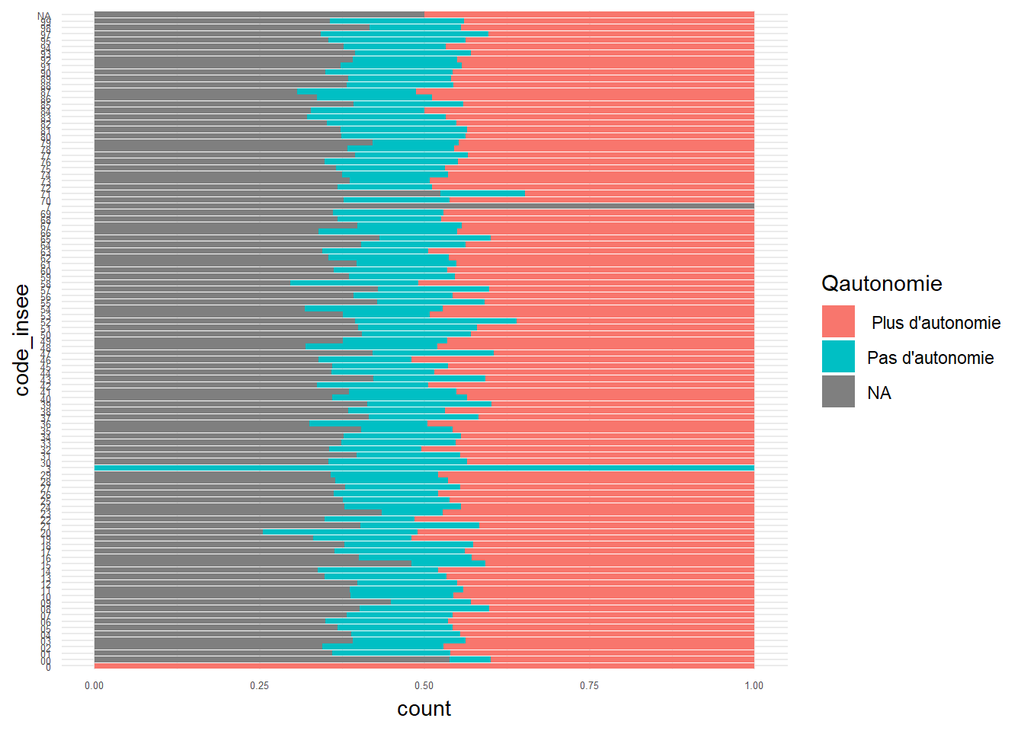

# Eléments de contenu des documents

## Distribution quantitative du contenu

Une distribution inégale du volume de contribution est mesurée au travers du nombre de signes. Un quart des contributeurs génère les 3/4 du volume de texte.

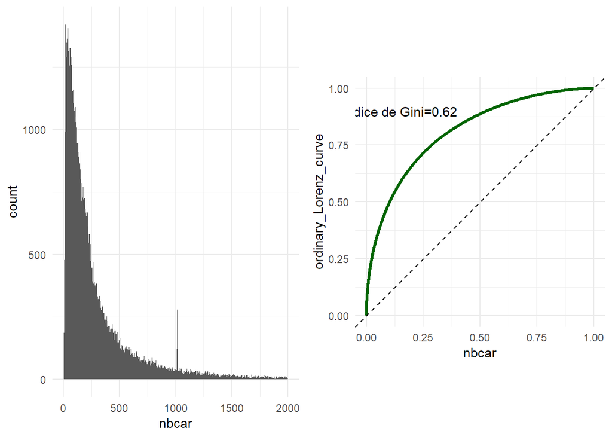

## WordCloud

Pour finir un premier aperçu du contenu avec un traitement de la question " que pensez vous de l’organisation de l’éTat et des services publiques ? "

controle par max_docfreq : éviter les termes trop nombreux. min_termfreq : la fréquence minimale d’apparition dans les documents.

```
##          collocation count count_nested length   lambda        z
## 1                y a  6395         6394      2 6.311811 280.0904
## 2            il faut 14026        13522      2 7.478199 267.8470
## 3               il y  6214         6200      2 5.486939 254.5472
## 4              de la 23328        23314      2 2.021264 254.0463
## 5   services publics  3722         3676      2 6.881170 220.6241
## 6             ce qui  4494         4433      2 4.007332 216.4471
## 7          le nombre  5522         5517      2 4.606693 211.9333
## 8            trop de 11890        11783      2 2.451435 209.3451
## 9          au niveau  3304         3285      2 5.317467 204.2822
## 10       par exemple  3583         2563      2 5.772431 203.9301
## 11    service public  2076         2026      2 6.257721 201.5152
## 12     beaucoup trop  2870         2855      2 5.092333 197.8085
## 13 fonction publique  1875         1861      2 7.510488 196.6994
## 14         n'est pas  3696         3687      2 5.857825 193.4586
## 15          tous les  5716         5485      2 4.129634 188.4123
```

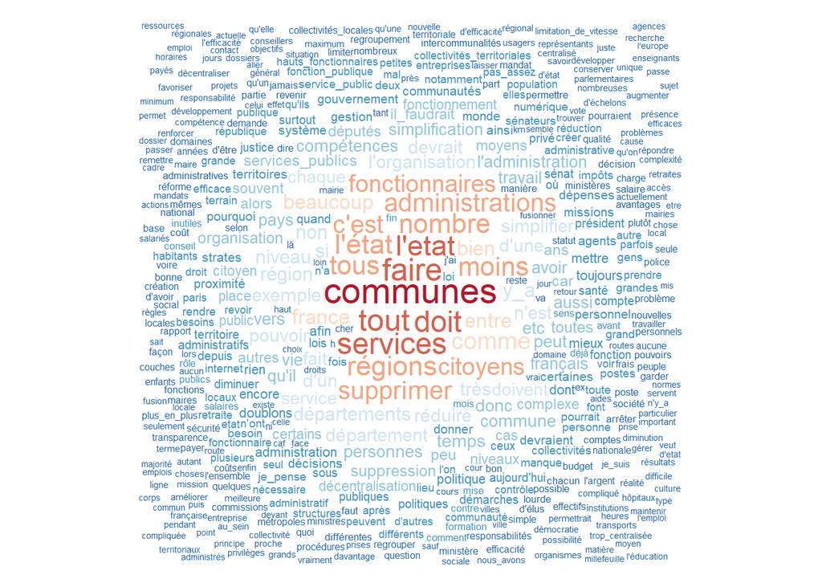

De manière équivalente la liste des mots les plus fréquents.

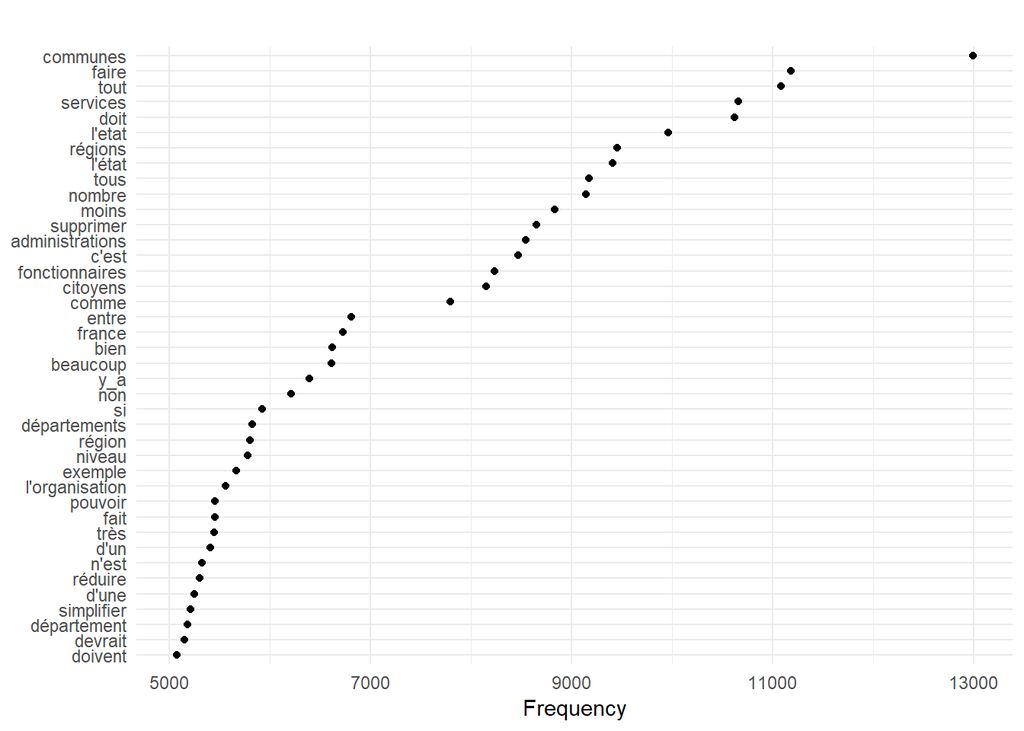

## Key Word Index

et pour conclure, retour au texte, un coup d’oeil sur le contexte de deux mots clés : décentralisation et autonomie.

| docname | from | to | pre | keyword | post | pattern |
| --- | --- | --- | --- | --- | --- | --- |
| text50 | 35 | 35 | à la réalité du terrain.Une | décentralisation | permettrait de mieux adapter et | Décentralisation |
| text109 | 124 | 124 | . Organiser une plus grande | décentralisation | en redéfinissant les missions de | Décentralisation |
| text109 | 1236 | 1236 | . Laïcité . Péréquation et | décentralisation | . ) . Subsidiarité . | Décentralisation |
| text157 | 11 | 11 | recouvrement des diverses administrations . | Décentralisation | , regroupement des services ( | Décentralisation |
| text266 | 1 | 1 |  | Décentralisation | non maîtrisée , source d’inégalités | Décentralisation |
| text348 | 33 | 33 | 9 ) Faut-il renforcer la | décentralisation | et donner plus de pouvoir | Décentralisation |
| text429 | 4 | 4 | Reforme de la | décentralisation | . " Réduire le mille-feuilles | Décentralisation |
| text429 | 58 | 58 | afin d ’ assurer une | décentralisation | territoriale . - Accélérer les | Décentralisation |
| text464 | 5 | 5 | Il faut poursuivre la | décentralisation | des instances étatiques et donner | Décentralisation |
| text506 | 92 | 92 | population . - Augmenter la | décentralisation | des services de l’Etat sauf | Décentralisation |
| text577 | 3 | 3 | davantage de | décentralisation |  | Décentralisation |
| text590 | 534 | 534 | dans le cadre de la | décentralisation | voulut par le traité de | Décentralisation |
| text595 | 26 | 26 | et la volonté . La | décentralisation | est intéressante pour la couverture | Décentralisation |
| text602 | 3 | 3 | Renforcer la | décentralisation |  | Décentralisation |
| text603 | 28 | 28 | moins fusion des Départements - | Décentralisation | de l’ensemble des administrations au | Décentralisation |
| text609 | 2 | 2 | La | décentralisation | initiée dans les années 80 | Décentralisation |
| text675 | 3 | 3 | Amplifier la | décentralisation | et simplifier l’organisation territoriale ; | Décentralisation |
| text676 | 265 | 265 | que soit engagée une vaste | décentralisation | vers les régions : décentralisation | Décentralisation |
| text676 | 270 | 270 | décentralisation vers les régions : | décentralisation | de nouvelles compétences ( éducation | Décentralisation |
| text681 | 13 | 13 | notamment au niveau de la | décentralisation | . Il faudrait réduire le | Décentralisation |

| docname | from | to | pre | keyword | post | pattern |
| --- | --- | --- | --- | --- | --- | --- |
| text15 | 254 | 254 | / Régions devront obtenir une | autonomie | complète de décision sans toujours | autonomie |
| text40 | 371 | 371 | canton suisses.Ils jouissent une grande | autonomie | dans le cadre des politiques | autonomie |
| text334 | 109 | 109 | de se voir maintenir leur | autonomie | et celle particulièrement financière visant | autonomie |
| text647 | 90 | 90 | . 2 . laisser une | autonomie | maximale aux régions pour décider | autonomie |
| text1340 | 31 | 31 | donnant les moyens de leur | autonomie | et conservant des " agences | autonomie |
| text2158 | 34 | 34 | régions devraient avoir une certaine | autonomie | ( comme en Espagne ) | autonomie |
| text2359 | 5 | 5 | Vers une plus grande | autonomie | régionale y compris pour le | autonomie |
| text2386 | 13 | 13 | décentralisation qui amène une véritable | autonomie | des régions ( historiques ) | autonomie |
| text2388 | 172 | 172 | communes qui devront avoir une | autonomie | maximale et un accès à | autonomie |
| text2573 | 37 | 37 | mais qui doivent gagner en | autonomie | et indépendance en professionnalisant les | autonomie |
| text2579 | 216 | 216 | dette et nous redonner notre | autonomie | budgétaire , abroger la loi | autonomie |
| text2790 | 43 | 43 | ) qui donnerait une véritable | autonomie | aux Régions actuelles plus proches | autonomie |
| text2990 | 143 | 143 | développer des politiques en pleine | autonomie | , dans un cadre clair | autonomie |
| text3176 | 45 | 45 | avoir un statut permettant une | autonomie | et des moyens au services | autonomie |
| text3244 | 59 | 59 | . Vers une plus grande | autonomie | des maires pour aider au | autonomie |
| text3310 | 80 | 80 | Le Canton dispose d’une forte | autonomie | . Par exemple , le | autonomie |
| text3326 | 45 | 45 | avoir un statut permettant une | autonomie | et des moyens au services | autonomie |
| text3688 | 40 | 40 | Bretagne devrait pouvoir avoir son | autonomie | comme la Polynésie Française avec | autonomie |
| text3758 | 74 | 74 | plus près du citoyen , | autonomie | locale : ( Ex : | autonomie |
| text3895 | 289 | 289 | devrait disparaitre au profit d’une | autonomie | des Établissements , animée au | autonomie |

# Références :

un site capital est https://statistiques-locales.insee.fr/#c=indicator&i=filosofi.med&s=2015&view=map1

http://leotrespeuch.com/2019/02/13/synthese-grand-debat-granddebat-fr/

Bennani, Hamza, Pauline Gandré, and Benjamin Monnery. 2019. “Les Déterminants Locaux de La Participation Numérique Au Grand Débat National: Une Analyse économétrique.” EconomiX Working Papers 2019-7. University of Paris Nanterre, EconomiX. https://EconPapers.repec.org/RePEc:drm:wpaper:2019-7.

Burns, Tom, and G. M. Stalker. 1994. *The Management of Innovation*. Rev. ed. Oxford ; New York: Oxford University Press.

Lawrence, Paul R., and Jay W. Lorsch. 1976. *Organization and Environment: Managing Differentiation and Integration*. 6. print. Boston, Mass: Harvard Business School Press.